# DATA VISUALIZATION

Raikibul Hasan

2021-12-10

# Contents

**Click on link for quick view:**

1. Data overview
   - 1.1 Fixing Car Data
2. Car Data Visualization
   - 2.1 Car Length VS Car Width
   - 2.2 Horsepoer and Car price
   - 2.3 Horsepower VS MPG in highway
   - 2.4 Horsepower VS MPG in city
   - 2.5 Drive wheel VS Weight
   - 2.6 Drive wheel VS Weight based on aspiration
   - 2.7 Number of car per company
   - 2.8 Car average price based on car company
   - 2.9 Top 5 expensive car company
   - 2.10 Car Engine size density plot
   - 2.10 Price density plot based on car body type
3. Conclusion

[figure not shown]

Car

# 1.Data overview

```
## # A tibble: 10 x 26
##    car_ID symboling CarName    fueltype aspiration doornumber carbody drivewheel
##     <dbl>     <dbl> <chr>      <chr>    <chr>      <chr>      <chr>   <chr>
##  1      1         3 alfa-rome~ gas      std        two        conver~ rwd
##  2      2         3 alfa-rome~ gas      std        two        conver~ rwd
##  3      3         1 alfa-rome~ gas      std        two        hatchb~ rwd
##  4      4         2 audi 100 ~ gas      std        four       sedan   fwd
##  5      5         2 audi 100ls gas      std        four       sedan   4wd
##  6      6         2 audi fox   gas      std        two        sedan   fwd
##  7      7         1 audi 100ls gas      std        four       sedan   fwd
##  8      8         1 audi 5000  gas      std        four       wagon   fwd
##  9      9         1 audi 4000  gas      turbo      four       sedan   fwd
## 10     10         0 audi 5000~ gas      turbo      two        hatchb~ 4wd
## # ... with 18 more variables: enginelocation <chr>, wheelbase <dbl>,
## #   carlength <dbl>, carwidth <dbl>, carheight <dbl>, curbweight <dbl>,
## #   enginetype <chr>, cylindernumber <chr>, enginesize <dbl>, fuelsystem <chr>,
## #   boreratio <dbl>, stroke <dbl>, compressionratio <dbl>, horsepower <dbl>,
## #   peakrpm <dbl>, citympg <dbl>, highwaympg <dbl>, price <dbl>
```

### 1.1 Fixing car data

##### 1.1.1 First of all I’ve renamed the column **carId** to **brandname** and take the brand name from car name by extracting the first word of the name.

```
## # A tibble: 10 x 26
##    brandname symboling CarName fueltype aspiration doornumber carbody drivewheel
##    <chr>         <dbl> <chr>   <chr>    <chr>      <chr>      <chr>   <chr>
##  1 alfa-rom~         3 alfa-r~ gas      std        two        conver~ rwd
##  2 alfa-rom~         3 alfa-r~ gas      std        two        conver~ rwd
##  3 alfa-rom~         1 alfa-r~ gas      std        two        hatchb~ rwd
##  4 audi              2 audi 1~ gas      std        four       sedan   fwd
##  5 audi              2 audi 1~ gas      std        four       sedan   4wd
##  6 audi              2 audi f~ gas      std        two        sedan   fwd
##  7 audi              1 audi 1~ gas      std        four       sedan   fwd
##  8 audi              1 audi 5~ gas      std        four       wagon   fwd
##  9 audi              1 audi 4~ gas      turbo      four       sedan   fwd
## 10 audi              0 audi 5~ gas      turbo      two        hatchb~ 4wd
## # ... with 18 more variables: enginelocation <chr>, wheelbase <dbl>,
## #   carlength <dbl>, carwidth <dbl>, carheight <dbl>, curbweight <dbl>,
## #   enginetype <chr>, cylindernumber <chr>, enginesize <dbl>, fuelsystem <chr>,
## #   boreratio <dbl>, stroke <dbl>, compressionratio <dbl>, horsepower <dbl>,
## #   peakrpm <dbl>, citympg <dbl>, highwaympg <dbl>, price <dbl>
```

##### 1.1.2 Afterwards I’ve duplicate listings and cleaned the columns. As example Some brand name of car are mixed by captilization and short from of name or spelling error.Like in row 10, maxda->mazda

```
## Before Cleaning  we have 28 brand name
```

```
## # A tibble: 28 x 2
##    brandname       n
##    <chr>       <int>
##  1 alfa-romero     3
##  2 audi            7
##  3 bmw             8
##  4 buick           8
##  5 chevrolet       3
##  6 dodge           9
##  7 honda          13
##  8 isuzu           4
##  9 jaguar          3
## 10 maxda           2
## # ... with 18 more rows
```

```
## After Cleaning  we have 22 brand name
```

```
## # A tibble: 22 x 2
##    brandname       n
##    <chr>       <int>
##  1 alfa-romero     3
##  2 audi            7
##  3 bmw             8
##  4 buick           8
##  5 chevrolet       3
##  6 dodge           9
##  7 honda          13
##  8 isuzu           4
##  9 jaguar          3
## 10 mazda          17
## # ... with 12 more rows
```

# 2.Car Data Visualization

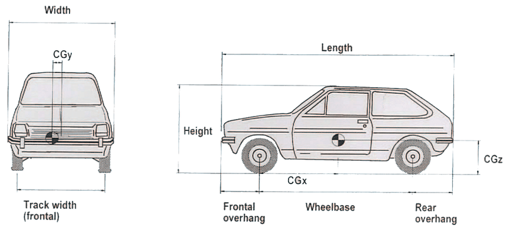

Car Dimension

### 2.1 From graph we can observe that lengthy car has more doors and wagon bodytypes of car are lengthy compare to others.

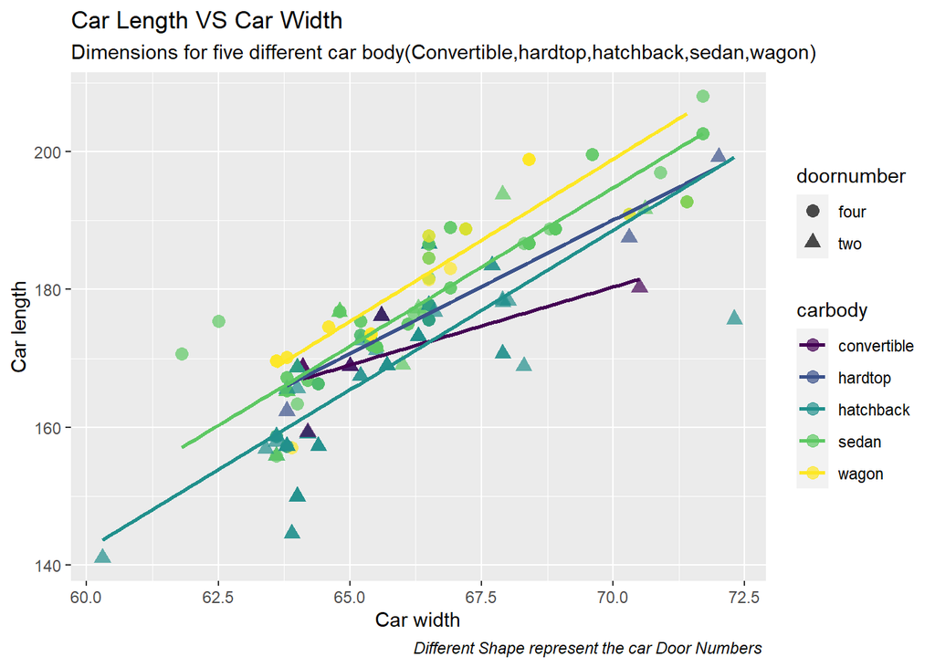

### 2.2 This visualization represnts that there is a positive co-relation between price and horsepower.

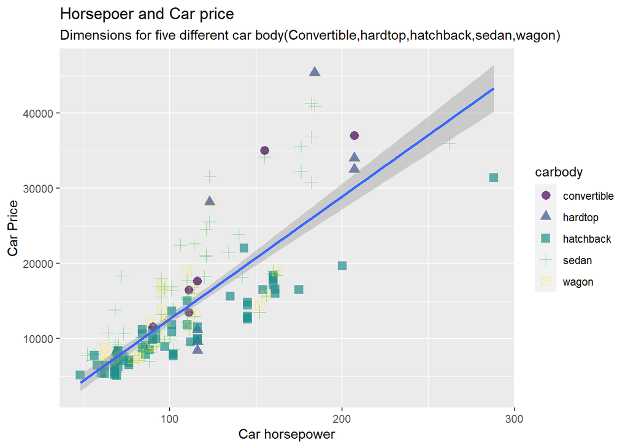

### 2.3 we can observe that which car has lower horsepower that has higher millage per gallon another ovservation is front-wheel drive cars get better mileage.

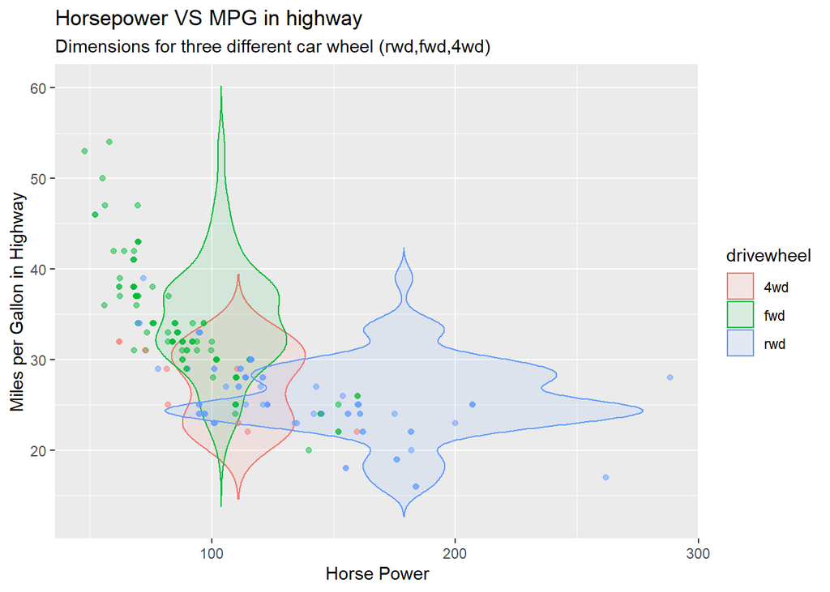

### 2.4 For city it illustrates same thing as before.

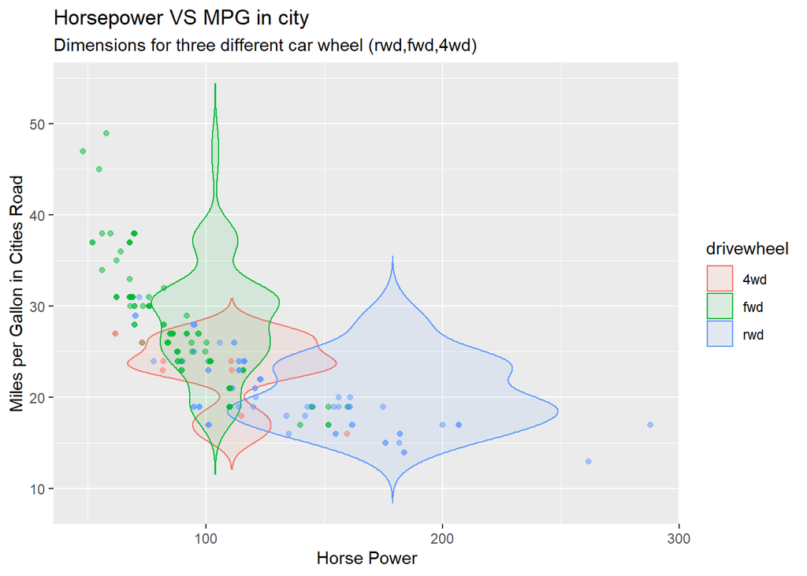

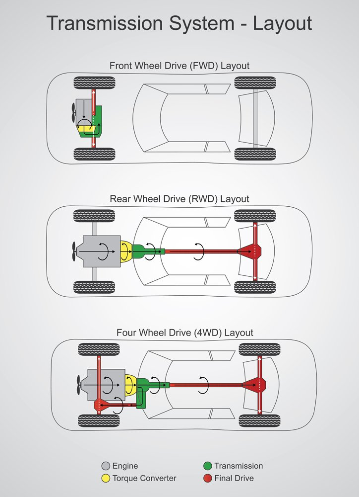

### 2.5 In previos graph we see that front-wheel drive cars get better mileage.From this graph we try to find out the reason why front-wheel drive car has better milage and this visualization represents that most of the time, front-wheel drive cars weight is less than that of a rear-wheel or 4wd car.

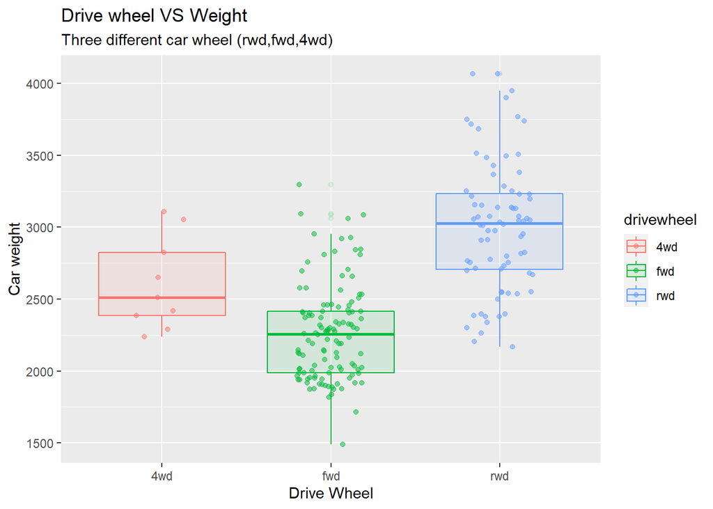

### 2.6 Visulization of box plot presents that turbocharger engine are heavier hence those car are more heavier.

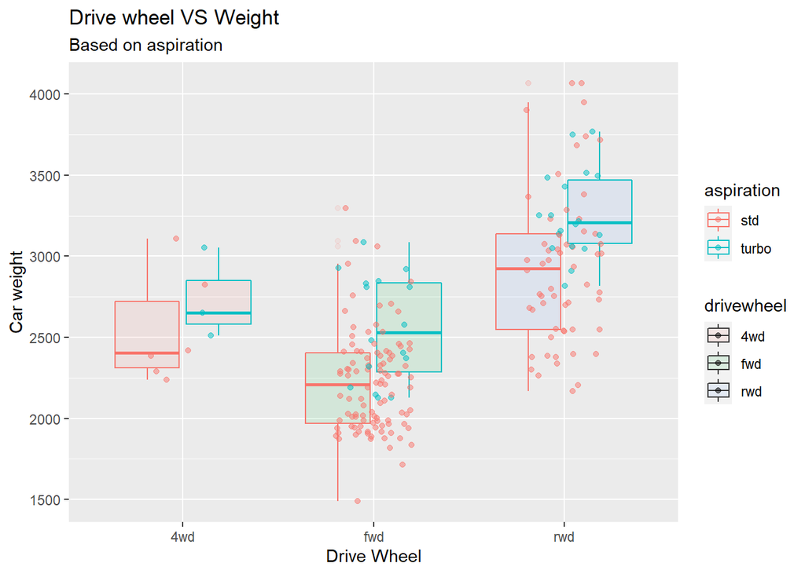

### 2.7 Number of car per company in this dataset also provide information about the fuel type of car.

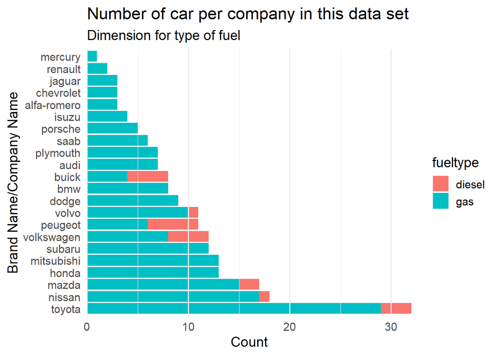

### 2.8 Car average price based on car company.

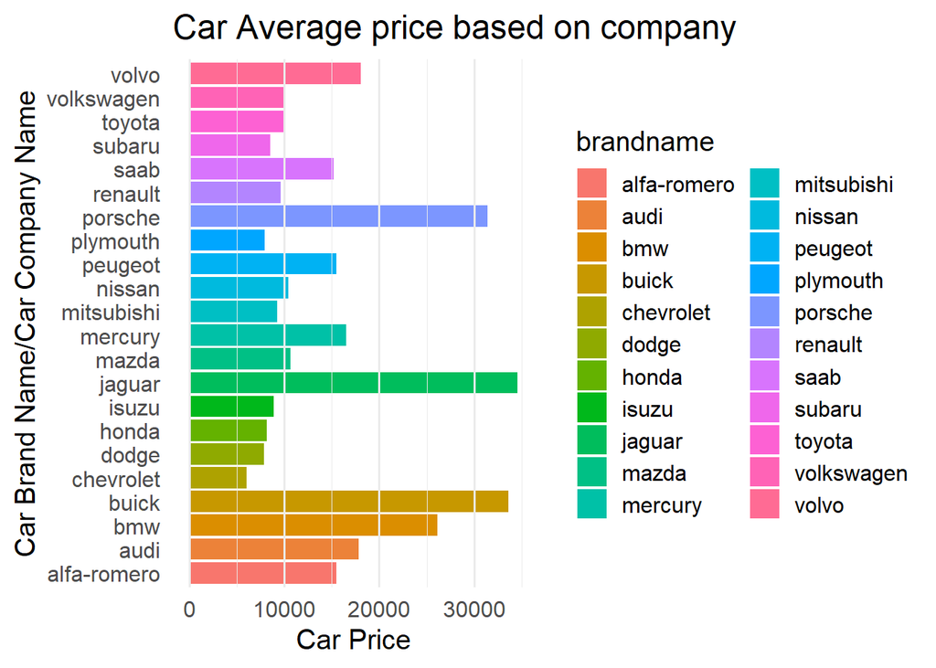

### 2.9 Top 5 expensive car company from the previous visualization.

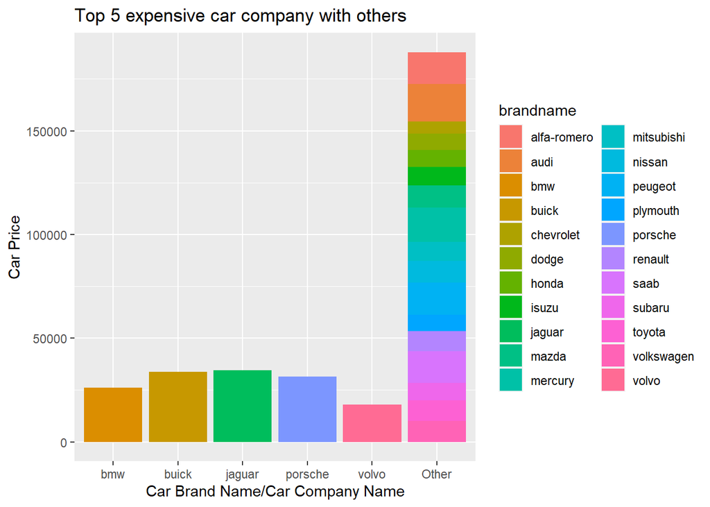

### 2.10 This visualization illustrates that most of the time light engine located in fronal of the car.

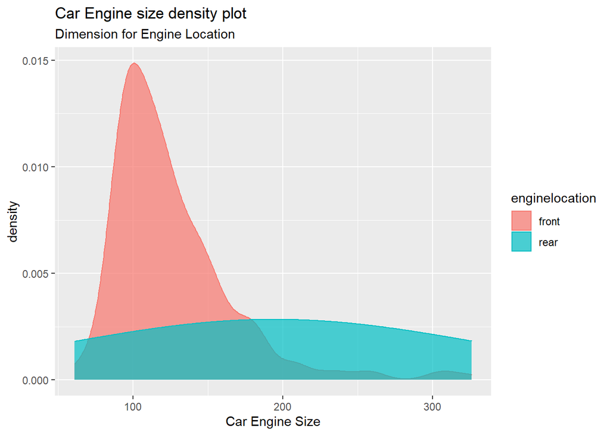

### 2.11 This visualization is about price density plot based on car body type.

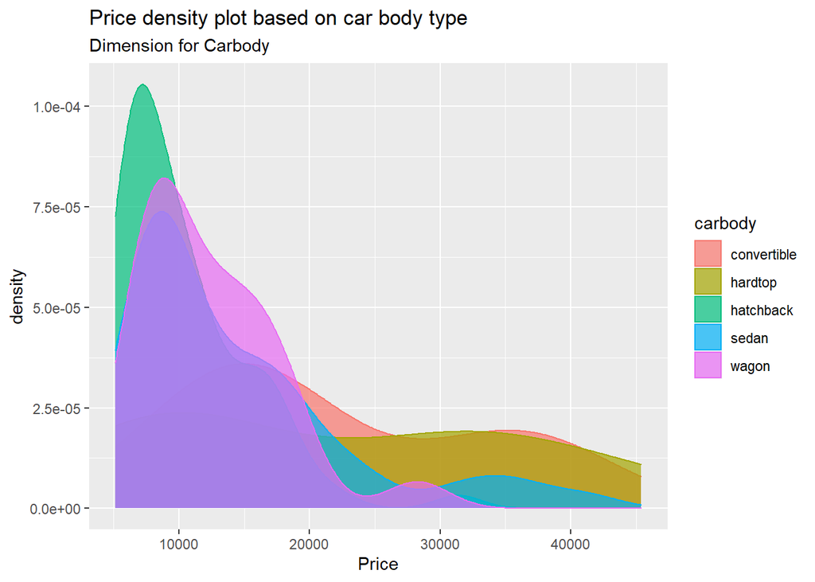

# 3.Conclusion

### In our Data Visualization course, I have learnt about the Grammar of Graphics,how to use ggplot2 for data visualization ,other package of R to visualize scatter plots,basic bar charts, histograms, pie charts,violin plots, line plots, box plots and how to further customize plots using themes.In this workshop, I try to analyse car data using those technique.By this visualization tools we can easily get a clear overview about car properties and performance with a quick view. To conclude, we can say that Data visualization is one of the useful technologies for data scientist.

Data Reference  
https://www.kaggle.com/goyalshalini93/car-data  
Image reference link  
1.https://www.researchgate.net/figure/Cars-dimensions-15_fig10_252035013  
2.https://www.scienceabc.com/innovation/what-is-a-four-wheel-drive-system-and-how-does-it-work.html

### Thanks to Roland Krause for this helpful course